신록예찬's 블로그

# (노트) CNN - hynn, iu

완성 (env:2021bda)

Aug 27, 2021 • 신록예찬 • 5 min read

fastai 딥러닝

- install pkgs
- import
- Image Crawling
- Interpretation
- Test
- Cleaner
- Deploy
- publish
- download data (cat and dog images)
- my first model
- 오답분석

### install pkgs

```python
#!pip install graphviz
#!conda install -c conda-forge jupyterlab_widgets -y
#!conda install -c conda-forge ipywidgets -y
#!conda install -c conda-forge nodejs -y
```

### import

```python
from fastai.vision.all import *
```

`-` https://github.com/fastai/fastbook/blob/master/utils.py 에서 search_images_ddf() 함수를 참고

```python
def search_images_ddg(key,max_n=200):
    """Search for 'key' with DuckDuckGo and return a unique urls of 'max_n' images
       (Adopted from https://github.com/deepanprabhu/duckduckgo-images-api)
    """
    url        = 'https://duckduckgo.com/'
    params     = {'q':key}
    res        = requests.post(url,data=params)
    searchObj  = re.search(r'vqd=([\d-]+)\&',res.text)
    if not searchObj: print('Token Parsing Failed !'); return
    requestUrl = url + 'i.js'
    headers    = {'User-Agent': 'Mozilla/5.0 (X11; Ubuntu; Linux x86_64; rv:71.0) Gecko/20100101 Firefox/71.0'}
    params     = (('l','us-en'),('o','json'),('q',key),('vqd',searchObj.group(1)),('f',',,,'),('p','1'),('v7exp','a'))
    urls       = []
    while True:
        try:
            res  = requests.get(requestUrl,headers=headers,params=params)
            data = json.loads(res.text)
            for obj in data['results']:
                urls.append(obj['image'])
                max_n = max_n - 1
                if max_n < 1: return L(set(urls))     # dedupe
            if 'next' not in data: return L(set(urls))
            requestUrl = url + data['next']
        except:
            pass
```

`-` ref: https://github.com/fastai/fastai2/blob/master/fastai2/data/external.py

```python
def download_url(url, dest, overwrite=False, pbar=None, show_progress=True, chunk_size=1024*1024,
                 timeout=4, retries=5):
    "Download `url` to `dest` unless it exists and not `overwrite`"
    if os.path.exists(dest) and not overwrite: return

    s = requests.Session()
    s.mount('http://',requests.adapters.HTTPAdapter(max_retries=retries))
    # additional line to identify as a firefox browser, see fastai/#2438
    s.headers.update({'User-Agent': 'Mozilla/5.0 (X11; Ubuntu; Linux x86_64; rv:71.0) Gecko/20100101 Firefox/71.0'})
    u = s.get(url, stream=True, timeout=timeout)
    try: file_size = int(u.headers["Content-Length"])
    except: show_progress = False

    with open(dest, 'wb') as f:
        nbytes = 0
        if show_progress: pbar = progress_bar(range(file_size), leave=False, parent=pbar)
        try:
            if show_progress: pbar.update(0)
            for chunk in u.iter_content(chunk_size=chunk_size):
                nbytes += len(chunk)
                if show_progress: pbar.update(nbytes)
                f.write(chunk)
        except requests.exceptions.ConnectionError as e:
            fname = url.split('/')[-1]
            data_dir = dest.parent
            print(f'\n Download of {url} has failed after {retries} retries\n'
                  f' Fix the download manually:\n'
                  f'$ mkdir -p {data_dir}\n'
                  f'$ cd {data_dir}\n'
                  f'$ wget -c {url}\n'
                  f'$ tar xf {fname}\n'
                  f' And re-run your code once the download is successful\n')
```

### Image Crawling

```python
urls = search_images_ddg('hynn', max_n=10)
len(urls),urls[0]
```

```
(10, 'https://www.nautiljon.com/images/people/01/59/hynn_99095.jpg?0')
```

```python
urls
```

```
(#10) ['https://www.nautiljon.com/images/people/01/59/hynn_99095.jpg?0','https://lastfm.freetls.fastly.net/i/u/770x0/f6744fc617da497938bf0560c82fe0d2.jpg#f6744fc617da497938bf0560c82fe0d2','https://kpopwiki.org/wp-content/uploads/2020/11/1593389807052.jpg','https://images.genius.com/a37e8f087886e8a9f…
```

```python
# for i in range(len(urls)):
#     download_url(urls[i],'temp%s.jpg' % i)
#     imgs=imgs+[Image.open('temp%s.jpg' % i)]
#     imgs[i].thumbnail((256,256))
```

```python
keywords='hynn','iu'
path=Path('singer')
```

```python
if not path.exists():
    path.mkdir()
    for keyword in keywords:
        lastpath=(path/keyword)
        lastpath.mkdir(exist_ok=True)
        urls=search_images_ddg(keyword,max_n=200)
        download_images(lastpath,urls=urls)
```

```python
fns=get_image_files(path)
```

```python
failed=verify_images(fns)
```

```python
failed
```

```
(#0) []
```

```python
failed.map(Path.unlink);
```

```python
dls=ImageDataLoaders.from_folder(
    path,
    train='singer',
    valid_pct=0.2,
    item_tfms=Resize(228))
```

- 이것은 아래와 같은 코드임

  ```
  singer=DataBlock(
    blocks=(ImageBlock,CategoryBlock),
    get_items=get_image_files,
    splitter=RandomSplitter(valid_pct=0.2,seed=42),
    get_y=parent_label,
    item_tfms=Resize(228))
  dls=singer.dataloaders(path)
  ```

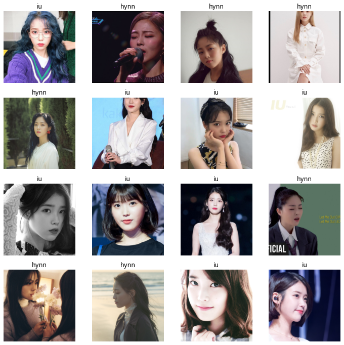

```python
dls.valid.show_batch(max_n=16)
```

```python
learn=cnn_learner(dls,resnet18,metrics=error_rate)
learn.fine_tune(20)
```

| epoch | train_loss | valid_loss | error_rate | time |
| --- | --- | --- | --- | --- |
| 0 | 1.089836 | 0.568197 | 0.158537 | 00:05 |

| epoch | train_loss | valid_loss | error_rate | time |
| --- | --- | --- | --- | --- |
| 0 | 0.597480 | 0.554288 | 0.158537 | 00:04 |
| 1 | 0.518040 | 0.410621 | 0.109756 | 00:04 |
| 2 | 0.443718 | 0.282546 | 0.109756 | 00:04 |
| 3 | 0.373817 | 0.186377 | 0.073171 | 00:04 |
| 4 | 0.309710 | 0.156164 | 0.060976 | 00:04 |
| 5 | 0.258422 | 0.149754 | 0.073171 | 00:04 |
| 6 | 0.218977 | 0.128645 | 0.048780 | 00:04 |
| 7 | 0.188021 | 0.127415 | 0.060976 | 00:04 |
| 8 | 0.161827 | 0.137502 | 0.060976 | 00:04 |
| 9 | 0.139092 | 0.128172 | 0.048780 | 00:04 |
| 10 | 0.120975 | 0.112232 | 0.048780 | 00:04 |
| 11 | 0.105311 | 0.100534 | 0.036585 | 00:04 |
| 12 | 0.099191 | 0.128380 | 0.048780 | 00:04 |
| 13 | 0.088061 | 0.138198 | 0.036585 | 00:04 |
| 14 | 0.078594 | 0.138156 | 0.036585 | 00:04 |
| 15 | 0.069973 | 0.130028 | 0.024390 | 00:04 |
| 16 | 0.062644 | 0.119570 | 0.024390 | 00:04 |
| 17 | 0.055939 | 0.115521 | 0.024390 | 00:04 |
| 18 | 0.050313 | 0.113630 | 0.024390 | 00:04 |
| 19 | 0.045091 | 0.109772 | 0.024390 | 00:04 |

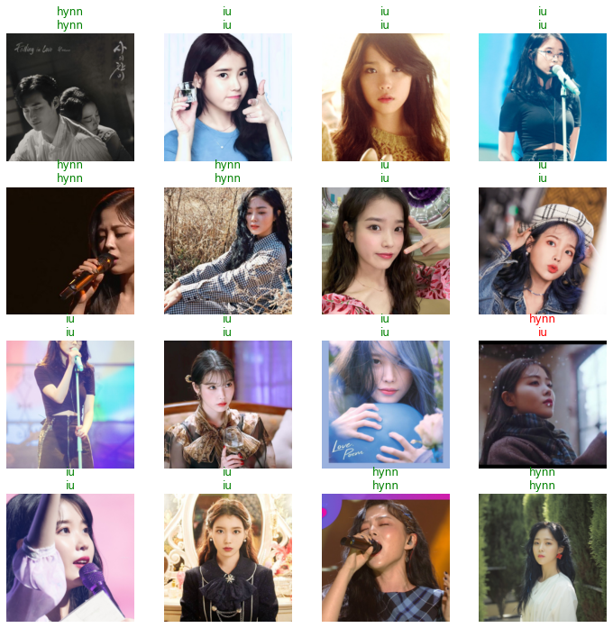

```python
learn.show_results(max_n=16)
```

### Interpretation

```python
interp = ClassificationInterpretation.from_learner(learn)
```

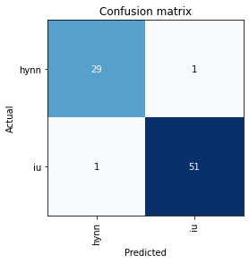

```python
interp.plot_confusion_matrix()
```

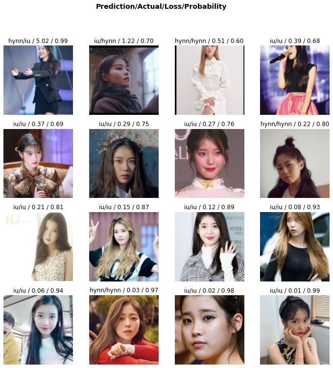

```python
interp.plot_top_losses(16)
```

```python
interp.most_confused()
```

```
[('hynn', 'iu', 1), ('iu', 'hynn', 1)]
```

`-` 수동으로 특정 observation에 대한 예측결과를 탐색하여 보자.

```python
dls.train_ds
```

```
(#328) [(PILImage mode=RGB size=946x634, TensorCategory(1)),(PILImage mode=RGB size=1024x1024, TensorCategory(1)),(PILImage mode=RGB size=599x583, TensorCategory(1)),(PILImage mode=RGB size=601x601, TensorCategory(1)),(PILImage mode=RGB size=1920x1200, TensorCategory(1)),(PILImage mode=RGB size=1280…
```

- traning set

```python
dls.train_ds[0]
```

```
(PILImage mode=RGB size=946x634, TensorCategory(1))
```

- first obs

[figure not shown]

```python
dls.train_ds[0][0]
```

- first image $x_1$

```python
x1=dls.train_ds[0][0]
x1?
```

```
Type:            PILImage
String form:     PILImage mode=RGB size=946x634
File:            ~/anaconda3/envs/2021bda/lib/python3.8/site-packages/fastai/vision/core.py
Docstring:       <no docstring>
Class docstring:
This class represents an image object.  To create
:py:class:`~PIL.Image.Image` objects, use the appropriate factory
functions.  There's hardly ever any reason to call the Image constructor
directly.

* :py:func:`~PIL.Image.open`
* :py:func:`~PIL.Image.new`
* :py:func:`~PIL.Image.frombytes`
```

- data type of $x_1$

```python
learn.predict(dls.train_ds[0][0])
```

```
('iu', tensor(1), tensor([4.8568e-06, 1.0000e+00]))
```

```python
learn.predict(dls.train_ds[115][0])
```

```
('hynn', tensor(0), tensor([9.9919e-01, 8.1303e-04]))
```

```python
learn.recorder.plot_loss
```

```
<bound method Recorder.plot_loss of Recorder>
```

### Test

```python
if not (path/'test').exists():
    (path/'test').mkdir()
```

```python
urls=search_images_ddg('박혜원',max_n=20)
download_images(path/'test',urls=urls)
testset=get_image_files(path/'test')
testset
```

```
(#21) [Path('singer/test/00000010.jpg'),Path('singer/test/00000005.jpg'),Path('singer/test/00000013.jpg'),Path('singer/test/00000011.jpg'),Path('singer/test/00000003.jpg'),Path('singer/test/00000000.jpg'),Path('singer/test/00000004.jpg'),Path('singer/test/00000016.jpg'),Path('singer/test/00000004.pn…
```

```python
for i in range(len(testset)):
    print(learn.predict(PILImage.create(get_image_files(path/'test')[i])))
```

```
('hynn', tensor(0), tensor([0.9476, 0.0524]))
```

```
('hynn', tensor(0), tensor([1.0000e+00, 2.6470e-06]))
```

```
('iu', tensor(1), tensor([0.1276, 0.8724]))
```

```
('iu', tensor(1), tensor([0.2912, 0.7088]))
```

```
('hynn', tensor(0), tensor([9.9925e-01, 7.5076e-04]))
```

```
('iu', tensor(1), tensor([0.0049, 0.9951]))
```

```
('hynn', tensor(0), tensor([0.5394, 0.4606]))
```

```
('hynn', tensor(0), tensor([9.9948e-01, 5.2236e-04]))
```

```
('hynn', tensor(0), tensor([0.5352, 0.4648]))
```

```
('iu', tensor(1), tensor([0.0548, 0.9452]))
```

```
('hynn', tensor(0), tensor([9.9968e-01, 3.2024e-04]))
```

```
('hynn', tensor(0), tensor([0.9975, 0.0025]))
```

```
('hynn', tensor(0), tensor([9.9997e-01, 3.3821e-05]))
```

```
('iu', tensor(1), tensor([0.1276, 0.8724]))
```

```
('hynn', tensor(0), tensor([1.0000e+00, 4.6541e-08]))
```

```
('hynn', tensor(0), tensor([9.9980e-01, 1.9960e-04]))
```

```
('hynn', tensor(0), tensor([9.9999e-01, 1.4012e-05]))
```

```
('iu', tensor(1), tensor([0.2032, 0.7968]))
```

```
('hynn', tensor(0), tensor([0.5399, 0.4601]))
```

```
('hynn', tensor(0), tensor([0.5172, 0.4828]))
```

```
('hynn', tensor(0), tensor([9.9992e-01, 8.2256e-05]))
```

```python
if not path.exists():
    path.mkdir()
    for keyword in keywords:
        lastpath=(path/keyword)
        lastpath.mkdir(exist_ok=True)
        urls=search_images_ddg(keyword,max_n=200)
        download_images(lastpath,urls=urls)
```

### Cleaner

```python
cleaner = ImageClassifierCleaner(learn)
```

```python
cleaner
```

```python
a=Image.open('temp.jpg')
```

```python
uploader=widgets.FileUpload()
display(uploader)
```

```python
img=PILImage.create(uploader.data[0])
is_cat,_,probs = learn.predict(img)
```

```python
is_cat
```

```python
probs
```

### Deploy

```python
uploader=widgets.FileUpload()
display(uploader)
```

```python
img=PILImage.create(uploader.data[0])
img
```

```python
pred,_,probs = learn.predict(img)
```

```python
pred,probs
```

### publish

```python
btn_upload = widgets.FileUpload()
btn_upload
```

```python
out_pl=widgets.Output()
# out_pl.clear_output()
# with out_pl: display(img.to_thumb(128,128))
# out_pl
```

```python
lbl_pred=widgets.Label()
```

```python
lbl_pred
```

```python
btn_run=widgets.Button(description='Classify')
btn_run
```

```python
def on_click_classify(change):
    img=PILImage.create(btn_upload.data[-1])
    out_pl.clear_output()
    with out_pl: display(img.to_thumb(128,128))
    pred,pred_idx,probs=learn.predict(img)
    lbl_pred.value=f'Prediction:{pred};Probability:{probs[pred_idx]:}'
btn_run.on_click(on_click_classify)
```

```python
VBox([widgets.Label('Select your bear!'),
      btn_upload, btn_run, out_pl, lbl_pred])
```

### download data (cat and dog images)

```python
path=untar_data(URLs.PETS)/'images'
```

```python
path
```

```python
path.ls()
```

> - `URLs.PETS`는 그냥 https://s3.amazonaws.com/fast-ai-imageclas/oxford-iiit-pet.tgz 가 저장된 스트링.. > - untar_data()는 fastai에서 제공하는 함수. URL주소를 str으로 받으면 PosixPath Type의 인스턴스를 반환한다.
> - PosixPath는 파이썬 자체에서 제공되는 자료형인듯. (이런건 [공식문서](https://docs.python.org/ko/3/library/pathlib.html)가 잘 정리되어있다.) > - PosixPath 타입은 `/` operator를 통해 문자열과 결합할 수 있음.
> - PosixPath 타입은 ls method를 통하여 path에 저장된 파일들의 목록을 출력할 수 있음

```python
files = get_image_files(path)
files
```

```python
files[0],files[1],files[2],files[3],files[4]
```

```python
def label_func(f):
    if f[0].isupper():
        return 'cat'
    else:
        return 'dog'
```

```python
label_func('asdf')
```

```python
dls = ImageDataLoaders.from_name_func(path, files, label_func, item_tfms=Resize(224)) ## 데이터로더는 좀더 탐구필요
# dls = ImageDataLoaders.from_name_func(
#     path, get_image_files(path),valid_pct=0.2, seed=42,
#     label_func=is_cat, item_tfms=Resize(224))
```

```python
dls.show_batch(max_n=9) # 실행할때마다 결과바뀜
```

[output not shown]

### my first model

```python
learn=cnn_learner(dls,resnet34, metrics=error_rate)
```

```python
learn.fine_tune(1)
```

[output not shown]

> CPU vs GPU 하면 좋을듯

```python
learn.predict(files[0])
```

```python
learn.show_results()
```

[output not shown]

### 오답분석

```python
interp = Interpretation.from_learner(learn)
```

```python
interp.plot_top_losses(16)
```

[output not shown]